# 607_Project2_Stock_Market

Ariann Chai

2023-10-05

## Data 607 Project 2: Stock Market Dataset

For this project, I will import three untidy datasets from our week 5 discussion board, tidy them, and analyze them. So first, I started by getting my libraries.

```r
library(dplyr)
```

```r
library(tidyr)
library(readr)
library(ggplot2)
```

## Stock Market Dataset

This second rmd file will be for the dataset is from Haig Bedros’s post and focuses on stock market. This dataset contains the oil and gold prices for different dates. It also contains what a bond that date will yield after different year period.

##Step 1: Import the dataset

```r
stockMarket <- read_csv("market_indicators.csv")
colnames(stockMarket)
```

```
## [1] "Date"              "dxy"               "oil"
## [4] "gold"              "treasury_5_years"  "treasury_10_years"
## [7] "treasury_30_years"
```

##Step 2: Tidy the dataset  
In order to tidy up this dataset and make it one observation per row, I ended up making 3 new different csvs: 1 for the oil price data, gold price data, and treasury year. These are all independent observations so they can not be on the same dataset. Oil and Gold were easy as I just subsetted the dataset with the couple columns needed. The clean ups are for columns that did not have any data of that new subset holds (oil,gold,treasury) but, probably held data for a different new subset data. For the treasury columns, I subsetted them into a new dataset and then used pivot_longer to combine them into 2 new columns.

```r
oilMarket_tidy <- subset(stockMarket, select = c(1,2,3))
oilMarket_tidy <-oilMarket_tidy[rowSums(is.na(oilMarket_tidy)) == 0, ]
oilMarket_tidy
```

```
## # A tibble: 3,464 × 3
##    Date         dxy   oil
##    <date>     <dbl> <dbl>
##  1 2009-03-31  85.4  49.7
##  2 2009-04-01  85.5  48.4
##  3 2009-04-02  84.4  52.6
##  4 2009-04-03  84.2  52.5
##  5 2009-04-06  84.6  51.0
##  6 2009-04-07  85.3  49.2
##  7 2009-04-08  85.4  49.4
##  8 2009-04-09  85.8  52.2
##  9 2009-04-13  84.6  50.0
## 10 2009-04-14  84.6  49.4
## # ℹ 3,454 more rows
```

```r
goldMarket_tidy <- subset(stockMarket, select = c(1,2,4))
goldMarket_tidy <-goldMarket_tidy[rowSums(is.na(goldMarket_tidy)) == 0, ]
goldMarket_tidy
```

```
## # A tibble: 3,462 × 3
##    Date         dxy  gold
##    <date>     <dbl> <dbl>
##  1 2009-03-31  85.4  923.
##  2 2009-04-01  85.5  926.
##  3 2009-04-02  84.4  907.
##  4 2009-04-03  84.2  896.
##  5 2009-04-06  84.6  872.
##  6 2009-04-07  85.3  882.
##  7 2009-04-08  85.4  885.
##  8 2009-04-09  85.8  882.
##  9 2009-04-13  84.6  895.
## 10 2009-04-14  84.6  891.
## # ℹ 3,452 more rows
```

```r
treasuryMarket <- subset(stockMarket, select = c(1,2,5,6,7))
treasuryMarket <-treasuryMarket[rowSums(is.na(treasuryMarket)) == 0, ]
treasuryMarket
```

```
## # A tibble: 3,462 × 5
##    Date         dxy treasury_5_years treasury_10_years treasury_30_years
##    <date>     <dbl>            <dbl>             <dbl>             <dbl>
##  1 2009-03-31  85.4             1.67              2.68              3.56
##  2 2009-04-01  85.5             1.65              2.66              3.49
##  3 2009-04-02  84.4             1.74              2.75              3.58
##  4 2009-04-03  84.2             1.88              2.91              3.72
##  5 2009-04-06  84.6             1.90              2.94              3.76
##  6 2009-04-07  85.3             1.86              2.91              3.73
##  7 2009-04-08  85.4             1.83              2.85              3.66
##  8 2009-04-09  85.8             1.89              2.93              3.76
##  9 2009-04-13  84.6             1.79              2.85              3.69
## 10 2009-04-14  84.6             1.72              2.79              3.66
## # ℹ 3,452 more rows
```

```r
treasuryMarket_tidy <-
  pivot_longer(treasuryMarket,
               cols=c('treasury_5_years', 'treasury_10_years', 'treasury_30_years'),
               names_to = 'Treasury Year',
               values_to = 'Amount')
treasuryMarket_tidy <- treasuryMarket_tidy[order(treasuryMarket_tidy$Date),]
#clean up the Treasury Year names replace?
treasuryMarket_tidy$`Treasury Year`[which(treasuryMarket_tidy$`Treasury Year`=="treasury_5_years")] <- 5
treasuryMarket_tidy$`Treasury Year`[which(treasuryMarket_tidy$`Treasury Year`=="treasury_10_years")] <- 10
treasuryMarket_tidy$`Treasury Year`[which(treasuryMarket_tidy$`Treasury Year`=="treasury_30_years")] <- 30
treasuryMarket_tidy
```

```
## # A tibble: 10,386 × 4
##    Date         dxy `Treasury Year` Amount
##    <date>     <dbl> <chr>            <dbl>
##  1 2009-03-31  85.4 5                 1.67
##  2 2009-03-31  85.4 10                2.68
##  3 2009-03-31  85.4 30                3.56
##  4 2009-04-01  85.5 5                 1.65
##  5 2009-04-01  85.5 10                2.66
##  6 2009-04-01  85.5 30                3.49
##  7 2009-04-02  84.4 5                 1.74
##  8 2009-04-02  84.4 10                2.75
##  9 2009-04-02  84.4 30                3.58
## 10 2009-04-03  84.2 5                 1.88
## # ℹ 10,376 more rows
```

```r
write.csv(oilMarket_tidy,file='/Users/Ari/Data607/project2/oilMarket_tidy.csv')
write.csv(goldMarket_tidy,file='/Users/Ari/Data607/project2/goldMarket_tidy.csv')
write.csv(treasuryMarket_tidy,file='/Users/Ari/Data607/project2/treasuryMarket_tidy.csv')
```

##Step 3: Analysis  
I believe since this data uses dates as a main key and is then recording data throughout a time period. Line graphs will be perfect to display and analyize this data.

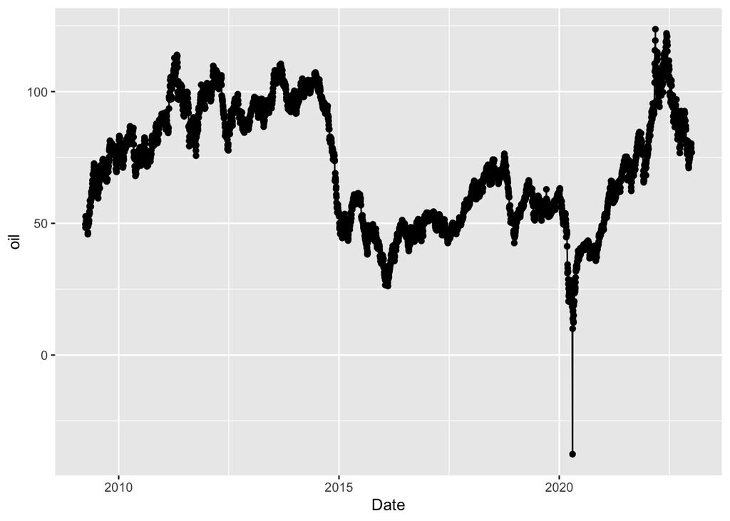

```r
ggplot(data=oilMarket_tidy, aes(x=Date, y=oil)) +
  geom_line()+
  geom_point()
```

The line graph above shows the price of oil throughout the dates. As expected, there is no pattern to the price hikes & dips. The oil price, however, mostly stays in the range of `$`40-125. It was going slowly up for a while until 2015 where it dipped and stabilized. There is one huge drop below `$`0 in early 2020. Interestingly, I think this weird drop is caused by the beginning of the pandemic. Since then, the price is increasing rapidly but, the end of graph shows a dip has started.

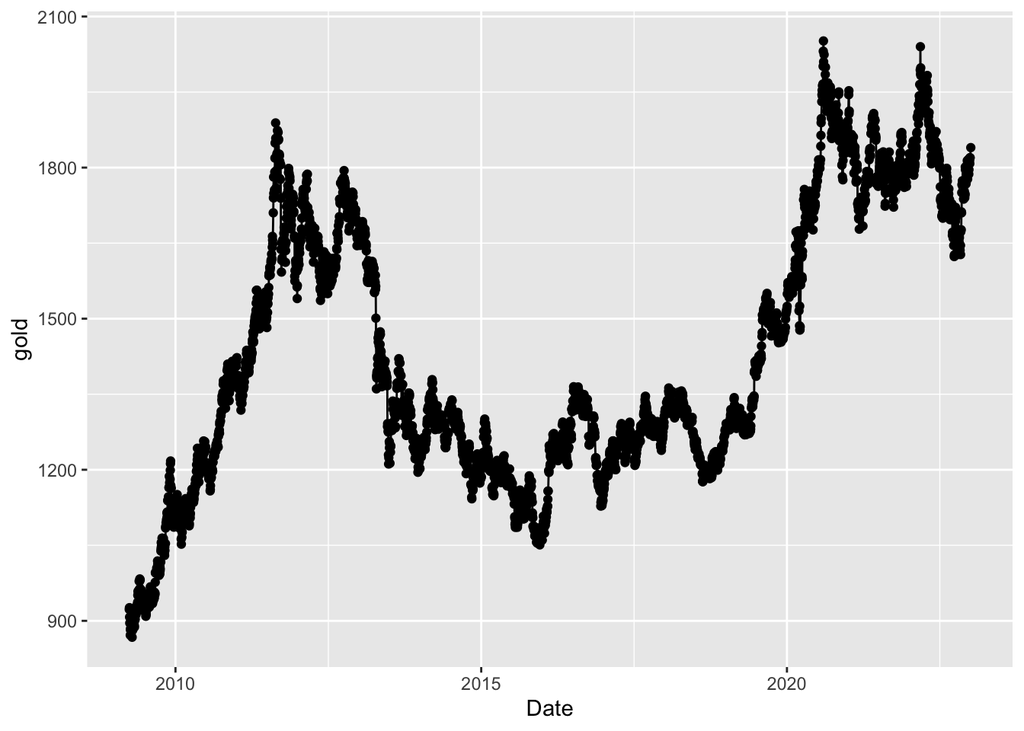

```r
ggplot(data=goldMarket_tidy, aes(x=Date, y=gold)) +
  geom_line()+
  geom_point()
```

The line graph above shows the price of gold throughout the dates. Unlike the oil prices, the gold price is rapidly changing and starts much higher. There are two hugely increasing hikes up around 2009-2012 and 2018-2021. These is also three time periods where the price is stable.

```r
colnames(treasuryMarket_tidy)
```

```
## [1] "Date"          "dxy"           "Treasury Year" "Amount"
```

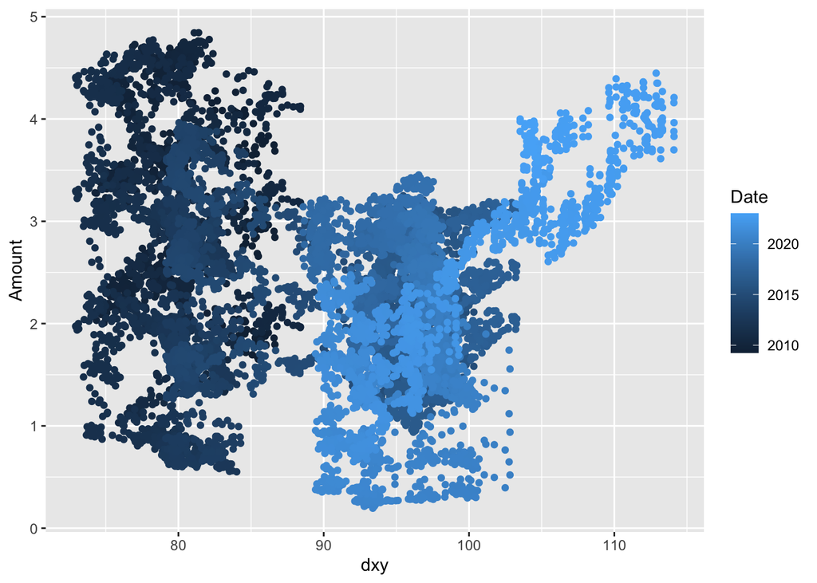

```r
ggplot(data=treasuryMarket_tidy, aes(x=dxy, y=Amount, color=Date)) +
  geom_point()
```